# Machine Learning Assessment

```python
# Hidden
import numpy as np
import matplotlib.pyplot as plt
import pandas as pd
```

```python
## Fix Random State
np.random.seed(0xDEAD)
```

```python
#HIDDEN
n_x = 20
pure_data = [x**1.9 for x in range(n_x) ]
noise = np.random.normal(0,7.0,n_x)
data = pure_data + noise
```

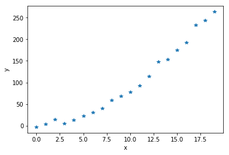

```python
#HIDDEN
plt.plot(data,'*')
plt.xlabel('x')
plt.ylabel('y')
plt.show()
```

**Answer the following questions regarding a fictitious training dataset plotted above with one input variable: $x$ and one output variable: $y$. The number of rows in the dataset is $n_x$.**

**Q1:** Suppose you want to fit a linear model (linear regression) to the data. The model will have the form: $$ \hat{y} = w_0 + w_1 *x $$

The model would take a particular value of $x_i$ as input and output $y_i$ as prediction.

To measure how closely the outputs $\hat y_i$ of your model approximate the actual output values $y_i$, you want to use the mean squared error between predicted and actual values as your cost function.

What will be the form of the cost function?

1. Cost = $ {1\over n_x} * \sum_{i=1}^{n_x} \lvert {y_i - \hat{y_i} \rvert} $
2. Cost = $ \sum_{i=1}^{n_x} (y_i - \hat{y_i})^2 $
3. Cost = $ {1\over n_x} * \sum_{i=1}^{n_x} (w_0 + w_1 *x_i - \hat{y_i})^2$
4. Cost = $ {1\over n_x} * \sum_{i=1}^{n_x} (w_0 + w_1 *x_i - y_i)^2$

**Answer:4**

**Q2:** Looking at the plot, the relationship between inputs and outputs might be non-linear as well. Suppose you want to fit a quadractic model (polynomial regression) to the data. So your model will have the form: $$ \hat{y} = w_0 + w_1 *x + w_2 *{x^2} $$

What will be the form of the cost function now?

1. Cost = $ {1\over n_x} * \sum_{i=1}^{n_x} \lvert {y_i - \hat{y_i} \rvert} $
2. Cost = $ {1\over n_x} * \sum_{i=1}^{n_x} (y_i - \hat{y_i}) $
3. Cost = $ {1\over n_x} * \sum_{i=1}^{n_x} (w_0 + w_1 *x_i + w_2 *{x_i^2} - y_i)^2$
4. Cost = $ \sum_{i=1}^{n_x} (y_i - \hat{y_i})^2 $

**Answer:3**

**Q3:** In the previous case you are concerned that the quadratic model might overfit your training data and might not perform well on unseen data. Suppose you want to add L1 regularization to your cost. What will be the new cost **Cost'** be if the regularization hyper-parameter is $\lambda$ [Assuming that the bias term in your model does not need regularization]?

1. Cost' = $Cost + \lambda*\lvert w_1 \rvert$
2. Cost' = $Cost + \lambda*(w_0 + w_1)$
3. Cost' = $Cost + \lambda*(\lvert w_0 + w_1 \rvert)$
4. Cost' = $Cost + \lambda*(\lvert w_0 \rvert)$

**Answer: 1**

**Q4:** If you apply L2 regularization to your model, What will be the new cost function **Cost'** if the regularization hyper-parameter is $\lambda$?

1. Cost' = $Cost + \lambda*(w_0 + w_1)^2$
2. Cost' = $Cost + \lambda*\sqrt{(w_0^2 + w_1^2)}$
3. Cost' = $Cost + \lambda*w_1^2$
4. Cost' = $Cost + \lambda*w_0^2$

**Answer:3**

**Q5:** In Q1, Q2, Q3 and Q4, what is the number of gradients of the cost with respect to model parameters?

1. 1, 1, 2, 3
2. 2, 2, 3, 3
3. 2, 2, 2, 2
4. 2, 2, 4, 4

**Answer:2**

**Q6:** What could cause a quadratic model to be more susceptible to overfitting over a linear model [Multiple options may be correct]?

1. Higher variance
2. Higher bias
3. Higher number of parameters.
4. Lower variance

**Answer: 1,3**

**Q7:**You train two different binary classification models M1 and M2 to identify abnormal heart sounds from normal ones (phonocardiogram or PCG data). To pick the best model you evaluate their performance on a held-out validation set. The validation set has 9000 PCG recordings out of which 8847 are normal while only 153 are abnormal. The tables below summarize the performance of the two models.

| Model:M1 | Predicted as Normal | Predicted as Abnormal |
| --- | --- | --- |
| Actually Normal | 8812 | 35 |
| Actually Abnormal | 42 | 111 |

[output not shown]

Which model is likely to perform better on a test set if we want to equally balance both precision and recall?

1. M1
2. M2

**Answer: 2 (Dataset is higly skewed. M2 has higher F1 score )**

**Q8:** You have a dataset with 500 rows where each row is a $16px*16px$ image of a traffic light flattened into a row vector with 256 features. The data is stored in a matrix $X$ with 500 rows and 256 columns. You want to predict whether the traffic light is green $(\hat y = 0)$, yellow $(\hat y = 1)$ or red $(\hat y = 2)$. When using a fully connected neural network with a single hidden layer that has 32 neurons what will be the total number of trainable parameters (weights and biases) in the model?

1. $(256+1) * 32 + (32+1) * 3$
2. $ 256 * 32 + 32 * 3 $
3. $ 256 * (32+1) + 32 * (3+1) $
4. $ 256*32*3 $

**Answer:1**

**Q9:** You are training a machine learning model to perform binary classification. The dataset has 2000 rows with 735 positive examples and 1265 negative examples. You randomly split the 2000 rows in to a training set with 1200 rows test set with 800 rows. You train the model for 10, 25 and 100 and 500 epochs and the training accuracies you get are 41.67%, 91.71% and 91.77% and 92.10%. What are the possible next steps in trying to debug your model / training process?

1. Use a different split with more data in the training set and less data in the test set, say 1500 and 500 rows.
2. Increase the number of parameters in your model.
3. Reduce the threshold of the classifier.
4. Lower the learning rate.

**Answer:2**

You are given a dataset with 2 features $f_0$ and $f_1$ and label $y$ = 0 or 1. The dataset is already split into train and test sets available to you as numpy array variables **q10_train** and **q10_test**. The first two columns in these arrays are the features $f_0$ and $f_1$ and the third column is the label $y$. You also have access to sklearn library (version >= 0.19). Create a classifier using `DecisionTreeClassifier('entropy')` API using 'entropy' as thhe criterion and default values for other parameters and fit it to the training set and answer the following questions using this information.

```python
# Hidden
from sklearn.tree import DecisionTreeClassifier
q10_train = np.load('q10_train.npy')
q10_test  = np.load('q10_test.npy')
```

**Q10:** Which feature is used by the decision tree to make the first split?

1. $f_0$ (column 0 of the dataset)
2. $f_1$ (column 1 of the dataset)

**Answer:1**

**Q11:** In Q10 what is the approximate threshold at which the feature is split?

1. 0.423
2. 0.735
3. 0.198
4. 0.389

**Answer:3**

**Q12:** What are the approximate values of the relative importances being assigned to the two features by this model?

1. 0.67, 0.33
2. 0.59, 0.41
3. 0.22, 0.78
4. 0.25, 0.75

**Answer:1**

**Q13:** What is the number of nodes in the tree and its depth?

1. 15,3
2. 19,7
3. 21,5
4. 23,7

**Answer:4**

**Q14:** What is the F1 score of this classifier on the training and test sets?

1. 0.96, 1.0
2. 0.5, 0.48
3. 1.0, 0.96
4. 1.0, 1.0

**Answer:3**

**Q15:** What is precision and recall of the model on the test set?

1. 0.93, 1.0
2. 0.39, 0.61
3. 1.0, 0.93
4. 0.61, 0.39 **Answer:1**

**Q16:** What is the value of entropy at the first split?

1. 0.98
2. 0.91
3. 0.99
4. 0.57

**Answer:2**

**Q17:** What is the number of false positives when this model is used to predict on the test set?

1. 0
2. 3
3. 1
4. 2

**Answer:3**

**Q18:** When trying to apply linear regression to non-linear data the training error will likely be quite high because:

1. linear regression has high variance.
2. linear regression has high bias.
3. mean squared error is not suitable for non-linear data.
4. gradient descent does not work when data is non-linear but the model is linear.

**Answer:2**

**Q19:** Which is not a hyperparameter of a decision tree and cannot be tuned using grid search?

1. Depth of the tree.
2. Minimum number of samples in a leaf node.
3. The feature used to make the first split (root node of the decision tree)
4. The minimum change (decrese) in imputiry for a split to be considered.

**Answer:3**

```python
from sklearn.metrics import confusion_matrix
from sklearn.metrics import f1_score
from sklearn.metrics import precision_score, recall_score

clf = DecisionTreeClassifier('entropy')
clf.fit(q10_train[:,range(2)], q10_train[:,2])

print(clf.tree_.node_count)
print(clf.tree_.threshold)
print(clf.feature_importances_ )
print(clf.tree_.feature)
print(clf.tree_.max_depth)
clf.tree_.impurity

from sklearn.metrics import accuracy_score
y_pred_test = clf.predict(q10_test[:,range(2)])
print(accuracy_score(q10_test[:,2],y_pred_test))
y_pred_train = clf.predict(q10_train[:,range(2)])
print(accuracy_score(q10_train[:,2],y_pred_train))


print(f1_score(q10_test[:,2].astype(np.uint8),y_pred_test))
print(f1_score(q10_train[:,2].astype(np.uint8),y_pred_train))
print(precision_score(q10_test[:,2].astype(np.uint8),y_pred_test))
print(recall_score(q10_test[:,2].astype(np.uint8),y_pred_test))

confusion_matrix(q10_test[:,2].astype(np.uint8),y_pred_test)

from sklearn import tree
tree.export_graphviz(clf)
!dot -T png tree.dot -o tree.png
```

```
23
[ 0.198155   -2.          0.82748497  0.33041     0.61521    -2.
  0.73502499 -2.         -2.          0.36520499  0.422515   -2.
 -2.          0.63479495  0.42281002  0.38940001 -2.         -2.
 -2.          0.83985996 -2.         -2.         -2.        ]
[0.69171703 0.30828297]
[ 0 -2  1  1  0 -2  0 -2 -2  0  1 -2 -2  0  0  0 -2 -2 -2  0 -2 -2 -2]
7
0.9473684210526315
1.0
0.962962962962963
1.0
0.9285714285714286
1.0
```

```python
# Hidden
vocab_q20 = list(np.load('mini_dict.npy').astype(np.str))
```

**Given a vocabulary (list of words) in the variable `vocab_q20`, calculate the frequency of each character (unigram) and the frequency of each character-pair present in the vocabulary (bi-gram) then answer the following questions. [Do not include whitespaces in your calculation]**

**Q20:** What is the conditional probability of character **`t`** being followed by character **`h`**, as in **thank**, **there**, **think**.?

1. 0.038
2. 0.077
3. 0.244
4. 0.0016

**Answer:2**

**Q21:** If we represent the probability in **Q20** as `P(h|t)`, calculate `P(e|h)`, `P(a|h)`, `P(n|e)`,`P(n|a)`, `P(m|e)` and `P(t|a)` as well. Assuming that the probability of a sequence of characteres $c_1 c_2... c_n$ is $P(c_2 \lvert c_1) * P(c_3 \lvert c_2) * ... * P(c_n \lvert c_{n-1})$, which of the following prefixes is more likely to occur according to the vocabulary?

1. them
2. then
3. than
4. that

**Answer:3**

**Q22:** Under the same assumption as in **Q22**, which sequence is more likely `married`,`marred`, `mrared` or `msrried` [Probability of the sequence divided by length of the sequence]?

1. married
2. marred
3. mrared
4. msrried

**Answer:2**

```python
unigram_freq = dict()
for word in list(vocab_q20):
    for char in word:
        if unigram_freq.get(char) is not None:
            unigram_freq[char] = unigram_freq[char] + 1
        else:
            unigram_freq[char] = 1

bigram_freq = dict()
for word in list(vocab_q20):
    for i in range(len(word)-1):
        bigram = word[i:i+2]
        if bigram_freq.get(bigram) is not None:
            bigram_freq[bigram] += 1
        else:
            bigram_freq[bigram] = 1

(unigram_freq['t']*unigram_freq['h'])/sum(list(unigram_freq.values()))**2

def get_prob(word):
    word_log_pb = 0.0
    for i in range(len(word)-1):
        unigram = word[i]
        bigram = word[i:i+2]

        bgram_fq = 0 if not bigram_freq.get(bigram) else bigram_freq[bigram]
        bgram_pb  = 0 if not bgram_fq else bgram_fq / unigram_freq[unigram]

        word_log_pb += np.log(bgram_pb)

    return word_log_pb / (len(word))

print(get_prob('them'),get_prob('then'),get_prob('than'),get_prob('that'))

print(get_prob('married'),get_prob('marred'),get_prob('mrared'),get_prob('msrried'))
```

```
-1.9149122639791052 -1.6336997842578636 -1.5859638560269207 -1.5964816595070923
-2.1497201046505436 -1.9506372580803113 -2.4600300739753824 -3.111933131924754
```

**Q23:** When a model is trained using mini-batches:

1. The cost for a minibatch is a function of fewer parameters (weights) compared to a full batch.
2. The cost for a minibatch is a function of all parameters (weights) but it is summed over a subset of the data.
3. Both 1 and 2 are true.
4. Neither 1, nor 2 is true.

**Answer:2**

**You are given a training set q24_train_X, q24_train_y with shapes 9500,784 and 9500,1 with 10 classes 0..9 in q24_train_y. A test set with 500 rows is available in q24_test_X and q24_test_y . Answer the following questions using these datasets.**

```python
#Hidden
fashion_train = np.load('fashion_train.npy')
fashion_test  = np.load('fashion_test.npy')
q24_train_X, q24_train_y = fashion_train[:,1:], fashion_train[:,0]
q24_test_X, q24_test_y = fashion_test[:,1:], fashion_test[:,0]
```

**Q24:** Fit a Gaussian Naive Baye's classifier (from sklearn) to the training data. What is the accuracy of the model on training and test sets?

1. 0.55, 0.60
2. 0.60, 0.55
3. 99.7, 91.1
4. 91.1, 99.7

**Answer:1**

**Q25:** The labels 0, 1, 2, .. 9 are described in the table below:

| label | description |
| --- | --- |
| 0 | T-shirt/top |
| 1 | Trouser |
| 2 | Pullover |
| 3 | Dress |
| 4 | Coat |
| 5 | Sandal |
| 6 | Shirt |
| 7 | Sneaker |
| 8 | Bag |
| 9 | Ankle boot |

What is the number of **Pullovers** misclassified as **Dresses** in the test set?

1. 3
2. 4
3. 15
4. 20

**Answer:2**

**Q26:** Which item in the test set is most often misclassified as **Sneaker**?

1. Pullover
2. Bag
3. Ankle Boot
4. Sandal

**Answer4:**

```python
from sklearn.naive_bayes import GaussianNB

clfnb = GaussianNB()

clfnb.fit(q24_train_X,q24_train_y)

print(clfnb.score(q24_test_X, q24_test_y))

print(accuracy_score(q24_train_y, clfnb.predict(q24_train_X)))

q24_pred_y = clfnb.predict(q24_test_X)

from sklearn.metrics import confusion_matrix

c = confusion_matrix(q24_test_y, q24_pred_y)
print(c[2,3])
print(np.argsort(c[:,7])[-2])
```

```
0.602
0.5508421052631579
4
5
```

```python
q27_train = np.load('q27_train.npy')
q27_test  = np.load('q27_test.npy')

q27_train_X, q27_train_y = q27_train[:,1:], q27_train[:,0]
q27_test_X, q27_test_y = q27_test[:,1:], q27_test[:,0]
```

**You are given a training set q27_train_X, q27_train_y with shapes (800,784) and (800,1) with 2 classes 0 and 1 in q27_train_y. A test set available in q27_test_X with labels in q27_test_y. Answer the following questions using these datasets.**

**Q27:** On the training data fit a logistic regression model from sklearn with `l2` penalty and `C` (inverse of regularization parameter) set to `1e-5`, other parameters set to default. Let us call it M1. Fit another model M2, again with `l2` penalty but `C` set to `1e-6`.

Which model has higher training accuracy and which model has higher test accuracy?

1. M1, M2
2. M1, M1
3. M2, M2
4. M2, M1

**Q28:** Which model has better precision and which one has better recall?

1. M1, M2
2. M1, M1
3. M2, M2
4. M2, M1

**Answer:4**

**Q29:** Which model has better $f_{\beta=0.5}$ score and which model has a better $f_{\beta=0.2}$ score [Use sklearn API and use the default parameter average='binary']?

1. M1, M2
2. M1, M1
3. M2, M2
4. M2, M1

**Answer:1**

**Q30:** Sklearn logistic regression classifier objects also produce class-wise probabilities for every prediction they make. Find the probabilities of the predicted class for all false negative cases in the test set. What percentage of the false negative predictions are made with over 90% confidence?

1. 65%
2. 40%
3. 33%
4. 90%

**Answer:3**

**Q31:** What is the approximate 90th percentile of the probabilities of the predicted (false negative) classes in **Q30**?

1. 65.0
2. 92.5
3. 90.0
4. 94.2

**Answer:2**

```python
from sklearn.linear_model import LogisticRegression

clflr1 = LogisticRegression(penalty='l2', C=1e-5)
clflr2 = LogisticRegression(penalty='l2', C=1e-6)

clflr1.fit(q27_train_X,q27_train_y)
clflr2.fit(q27_train_X,q27_train_y)

print(clflr1.score(q27_train_X, q27_train_y), clflr1.score(q27_test_X, q27_test_y), clflr2.score(q27_train_X, q27_train_y), clflr2.score(q27_test_X, q27_test_y))

clflr1.intercept_

from sklearn.metrics import precision_score, recall_score, fbeta_score, roc_auc_score

print(precision_score(q27_test_y, clflr1.predict(q27_test_X)), precision_score(q27_test_y, clflr2.predict(q27_test_X)))
print(recall_score(q27_test_y, clflr1.predict(q27_test_X)), recall_score(q27_test_y, clflr2.predict(q27_test_X)))
print(fbeta_score(q27_test_y, clflr1.predict(q27_test_X),beta=0.5), fbeta_score(q27_test_y, clflr2.predict(q27_test_X),beta=0.5))
print(fbeta_score(q27_test_y, clflr1.predict(q27_test_X),beta=0.2), fbeta_score(q27_test_y, clflr2.predict(q27_test_X),beta=0.2))

pred1 = clflr1.predict(q27_test_X)
prob1 = clflr1.predict_proba(q27_test_X)

prob1_fn = prob1[np.logical_and(q27_test_y==1,pred1==0)]

prob1_fn_max = np.max(prob1_fn,axis=1)

np.percentile(prob1_fn_max,90)

sorted(prob1_fn_max)
```

```
0.99125 0.9586776859504132 0.96375 0.9338842975206612
0.9444444444444444 1.0
0.6538461538461539 0.38461538461538464
0.8673469387755103 0.7575757575757577
0.9285714285714286 0.9420289855072465
```

```
[0.5052689349976345,
 0.5870860789497314,
 0.6374166177444025,
 0.6916524575917311,
 0.8203049428207164,
 0.8605697755994335,
 0.9022122604789338,
 0.9212112181486277,
 0.9383989850692951]
```

**Q32:** Fit a linear support vector machine classifier (SVC) to **q27_train_X,q27_train_y** [use SVC(kernel='linear') API from Sklearn instead of the LinearSVC() as the latter may cause results to change from one run to the next]. Which value of the regularization parameter `C` produces the smallest difference between train and test accuracies?

1. C=0.0000010
2. C=0.0000012
3. C=0.0000015
4. C=0.0000020

**Answer:2**

```python
from sklearn.svm import SVC

for c in [.0000010, .0000012, .0000015, .0000020]:
    clfrbf = SVC(kernel='linear',C=c)
    clfrbf.fit(q27_train_X, q27_train_y)
    print(c, clfrbf.score(q27_train_X,q27_train_y), clfrbf.score(q27_test_X, q27_test_y))
```

```
1e-06 0.985 0.9669421487603306
1.2e-06 0.98625 0.9710743801652892
1.5e-06 0.9875 0.9710743801652892
2e-06 0.99 0.9710743801652892
```

**Q33:** Using the value of C from **Q32** fit three different classifiers with 'linear', 'poly' and 'rbf' kernels on the same dataset: **q27_train_X,q27_train_y** [use SVC(kernel='linear') API from Sklearn instead of the LinearSVC() as the latter may cause results to change from one run to the next]. Which kernel produces the best training and test accuracies?

1. 'linear', 'linear'
2. 'rbf', 'linear'
3. 'poly', 'rbf'
4. 'poly', 'linear'

**Answer:4**

```python
from sklearn.svm import SVC

for k in ['linear', 'poly', 'rbf']:
    clfsvc = SVC(kernel=k,C=1.2e-6)
    clfsvc.fit(q27_train_X, q27_train_y)
    print(k, clfsvc.score(q27_train_X,q27_train_y), clfsvc.score(q27_test_X, q27_test_y), np.sum(clfsvc.n_support_))
```

```
linear 0.98625 0.9710743801652892 126
poly 1.0 0.9338842975206612 145
rbf 0.9075 0.8925619834710744 148
```

**Q34:** Concerning the three models from **Q33** which of the options below is true [More than one may be true]?

1. polynomial kernel badly overfits the training data
2. rbf kernel badly underfits the training data
3. both polynomial and rbf kernels badly overfit the training data
4. all models underfit the training data.

**Answer:1,2**

**Q:35**

Concerning the three models from **Q33** what is the number of support vectors of the models?

1. linear:126, poly:145, rbf:148
2. linear:118, poly:145, rbf:148
3. linear:112, poly:145, rbf:222
4. linear:140, poly:120, rbf:148

**Answer:1**

**Q36:** Fit a Random Forest classifier with `maxdepth=7` and `n_estimators=10` on q27_train_X, q27_train_y and evaluate the model on the corresponding set. Repeat this process a few time and observe that the performance of the Random Forest classifier (for example, train or test accuracy) varies each time, without there being any change in the parameters or hyperparameters. This happens because of the randomness inherent in the classifier. To get an idea of the mean performance of the model and the variation in the performance, fit and evaluate the model 100 times and store the test accuracies. What is the approximate value of the mean of these test accuracies.

1. 96%
2. 97%
3. 98%
4. 95%

**Answer:2**

**Q37:** Use this sample of 100 accuracies to bootstrap a 90% confidence interval for the mean test accuracy of the model (measured in %). What is the order of the width of the confidence interval?

1. $10^{-3}$
2. $10^{-2}$
3. $10^{-1}$
4. ${10^0}$

**Answer:3**

```python
from sklearn.ensemble import RandomForestClassifier
clfrf = RandomForestClassifier(max_depth=7,n_estimators=10)

sample_acc_train = []
sample_acc_test =  []

for i in range(100):
    clfrf.fit(q27_train_X,q27_train_y)
    sample_acc_train.append(100*clfrf.score(q27_train_X,q27_train_y))
    sample_acc_test.append(100*clfrf.score(q27_test_X,q27_test_y))

print(np.mean(sample_acc_test))

mean_test_accuracies = []
for i in range(100):
    bootstrap = np.random.choice(sample_acc_test,size=len(sample_acc_test))
    mean_test_accuracy = np.mean(bootstrap)
    mean_test_accuracies.append(mean_test_accuracy)

print(np.percentile(mean_test_accuracies,95)-np.percentile(mean_test_accuracies,5))
```

```
97.41322314049589
0.2320247933884616
```

**Answer:1**

**Q39:** Find the majority label in each cluster. In how many clusters, the fraction of majority label is >= 0.75?

1. 3
2. 2
3. 0
4. 8

**Answer:1**

```python
from sklearn.cluster import KMeans
clfkm = KMeans(n_clusters=10,random_state=0xdead)
clfkm_pred_train = clfkm.fit_predict(q24_train_X)

labels_by_cluster_id = np.zeros([10,10])
for cluster_id in range(10):
    for label in range(10):
        labels_by_cluster_id[cluster_id][label] = np.sum(q24_train_y[clfkm_pred_train==cluster_id] == label)

maj_label_count = np.max(labels_by_cluster_id, axis=1)
all_label_count = np.sum(labels_by_cluster_id, axis=1)
print(sum(maj_label_count/all_label_count >= 0.75))
```

```
3
```

**Q:40** The entropy of a distribution with $n$ uniqued iscrete elements may be defined as $$\sum_{i=1}^{n}-p_i*log_e(p_i)$$. What is the entropy of the training set (**q24_train_X**)? [Use scipy.stats.entropy(). It takes care of numerical stability and uses natural logarithm by default.]

1. 2.30
2. 3.02
3. 1.77
4. 0.96

**Answer:1**

**Q:41** Find the entropy of each of the clusters and find the weighted sum of these entropies (weighed by the ratio of the cluster size to the size of the whole data). Find the information gain by subtracting this weighted sum of entropies from the entropy of the whole dataset (calculated above) [Use scipy.stats.entropy(). It takes care of numerical stability and uses natural logarithm by default.]. What is the value of information gain?

1. 2.300
2. 1.157
3. 1.456
4. 0

```python
from scipy.stats import entropy

probs = np.histogram(q24_train_y,bins=range(11),density=True)[0]
ent_whole = entropy(probs)
print(ent_whole)

entropy_clusters = np.apply_along_axis(entropy, 1, np.divide(labels_by_cluster_id, np.sum(labels_by_cluster_id,1).reshape([-1,1]) ))

cluster_sizes = np.sum(labels_by_cluster_id,1)
cluster_sizes_norm = cluster_sizes / np.sum(cluster_sizes)
ent_clusters_cum = (np.dot(cluster_sizes_norm,entropy_clusters))
print(ent_clusters_cum)
print(ent_whole-ent_clusters_cum)
```

```
2.302562915744893
1.157017238942189
1.1455456768027037
```

**Q42:** The covariance between two row vectors $v_1$ and $v_2$ each having $N$ elements can be calculated as $(v_1-mean(v_1))\cdot (v_2-mean(v_2)) \over N$. A dataset $X_{nXd}$ has $n$ rows and $d$ features (columns) per row. Which of the following expressions will give the covariance matrix that contains the **covariance of every feature vector with every other feature vector**?

1. ${(X-colmean(X))^T \cdot (X-colmean(X))} \over N$
2. ${(X-rowmean(X))^T \cdot (X-rowmean(X))} \over N$
3. ${(X-colmean(X)) \cdot (X-colmean(X))^T} \over N$
4. ${(X-rowmean(X)) \cdot (X-rowmean(X))^T} \over N$

**Q43:** The data in Q24_train_X has more than 9000 rows and 784 columns. Reduce the number of features (dimensions) using PCA() from sklearn [Set the parameter random_state=0] so that 99% of the total variance is retained by the new features. How many features are present in the new dataset?

1. 28
2. 100
3. 99
4. 254

**Q44:** Suppose, instead we want to reduce the number of features down to 100. What percentage of the overall variance is retained by the 100 new features? [Set the parameter random_state=0 when suing PCA() from sklearn].

1. 93.7
2. 91.2
3. 95.6
4. 99.7

```python
from sklearn.decomposition import PCA

pca_0_99 = PCA(n_components=0.99,random_state=0)
pca_0_99.fit(q24_test_X)
print(pca_0_99.n_components_)

pca_100 = PCA(n_components=100,random_state=0)
pca_100.fit(q24_test_X)
print(np.sum(pca_100.explained_variance_ratio_))


q45_train_X = pca_100.transform(q24_train_X)

q45_train_X.shape
```

```
254
0.937305345620146
```

```
(9500, 100)
```

**Q45:** Fit a Gaussian Naive Bayes classifier to the transformed data from **Q44**. What is the percenteage change in training accuracy compared to the accuracy achieved in Q24?

1. >1%
2. >10%
3. >15%
4. >25%

**Answer:3**

```python
q45_train_y = q24_train_y
#clf45 = LogisticRegression()
clfnb.fit(q45_train_X, q45_train_y)
print(clfnb.score(q45_train_X, q45_train_y))
print(clfnb.score(pca_100.transform(q24_test_X), q24_test_y))
```

```
0.771578947368421
0.764
```

**Q46:** If $X$ is a matrix and $w$ is a column vector what is the derivative $\partial {(X \cdot w)} \over \partial w$?

1. $X^T$
2. $X$
3. $X^{-1}$
4. $\lvert X \rvert$

**Answer:2**

**Q47:** Consider the 1-D space on the real line in the interval [-1,1], centered at the origin (0,0), if there are $n$ points uniformly distributed on the line, the fraction of these points up to a distance 0.6 from the origin is expected to be 0.6. Now consider a circle of radius 1 with center at the origin having radius 1, and a smaller circle with the same center but a radius of 0.6, if there are $n$ uniformly distributed points inside the bigger circle, the fraction of those points lying inside the smaller circle too, is expected to be 0.36. In 3-D space, for a sphere with center (0,0,0) and radius 1 and a smaller sphere with the same center but radius 0.6, if there are $n$ points inside the larger sphere, the fraction of those points inside the smaller spehre is expected to be 0.216. Using this analogy in the case of of a 784-D space, if a hyperspehere has center (0,0,0) and radius 1, what should be the radius of a smaller hypersphere centered at (0,0,0) so that the fraction of points inside the smaller sphere is >0.9?

1. 0.9
2. 0.99
3. 0.999
4. 0.9999

**Answer:4**

**Suppose a neural network, designed for 3 target classes of sound recordings (0,1,2), has the activations $\begin{bmatrix} 0.65, -0.09, 0.34 \end{bmatrix}$ at its last layer for some input. If each example(instance) in the data can only belong to one of the 3 classes, for example recordings of individual musical instruments, the activations can be fed to a softmax activation layer that would produce a probability distribution across all classes. On the other hand, if the data can belong to more than one class, for example recording of many musical instruments playing simultaneously, the activations can be fed to a sigmoid activation that will produce a vector of probabilities for the instance to independently belong to each of the class. Answer the following questions using this information:**

**Q48:** If the activations are fed to a softmax, which target class is predicted?

1. 0
2. 1
3. 3
4. 2

**Q49:** If the activations are fed to a sigmoid, which target class(es) is/are predicted?

1. 0,1
2. 1,2
3. 0,2
4. 1

**Answer:3**

```python
a = np.array([0.65,-.09, 0.34])

def sigmoid(z):
    return 1. / (1. + np.exp(-z))

def softmax(z):
    return np.exp(-z) / np.sum(np.exp(-z))

sgm = sigmoid(a)
sfm = softmax(a)
print(sgm, sfm)
print(np.where(sgm>0.5), np.argmax(sfm))
```

```
[0.65701046 0.47751518 0.58419052] [0.22424739 0.47000808 0.30574453]
(array([0, 2]),) 1
```

**The gradient of a function $f(x)$ at $x=x_0$ can be either calculated as ${f(x_0+\epsilon) -f(x_0)} \over \epsilon$, using some small number $\epsilon$ or it can be derived using calculus and then evaluated at $x_0$, i.e. $g(x_0)$ such that $\int g(x) = f(x)$.**

**Q50:** Which of the following is most accurate regarding gradient descent?

1. Gradient descent uses the first approach for calculating gradients.
2. Gradient descent uses the second approach for calculating the gradients.
3. Gradient descent uses the first approach along with backpropagation to calculate gradients.
4. Gradient descent does not rely on gradients at all.

**Answer:3**

**You have access to an image dataset (q51_train_X, q51_train_y), (q51_test_X, q51_test_y). Each image belongs to exactly one class from [0,1,2,3,...9]. Keras is available as tf.keras and models, layers etc can be imported from tf.keras, for example, tf.keras.layers.Dense. Answer the following questions based on this information.**

```python
# Hidden
import tensorflow as tf
q51_train_X = q24_train_X
q51_train_y = q24_train_y
q51_test_X  = q24_test_X
q51_test_y  = q24_test_y
```

**Q51:** Use the training data (q51_train_X) to train a Keras classification model. Your model should have the following constraints

- Model has one hidden and one output layer.
- Hidden layer with 32 neurons and 'sigmoid' activation.
- Output layer with 10 neurons and an appropriate activation.
- Categorical cross entropy loss.
- SGD optimizer with default parameters.
- Accuracy as metric.
- Trained with minibatches of size 32.
- Trained for only 1 epoch.

Which of the following is true about the model?

1. On the training set, the model performs worse than random guessing.
2. If the size of the hidden layer is increased [64 -> 128 -> 256 -> 512 -> 1024], the training accuracy first increases then starts to go down.
3. The model has better accuracy on the test set compared to the train set.
4. Training accuracy increases linearly if the number of epochs is increased [1->10->100].

**Answer:3**

```python
Sequential = tf.keras.models.Sequential
Dense = tf.keras.layers.Dense

model51 = Sequential()

model51.add(Dense(32,activation='sigmoid',input_shape=(784,)))
model51.add(Dense(10,activation='softmax'))

model51.compile('SGD', 'categorical_crossentropy', ['accuracy'])

model51.fit(q51_train_X, tf.keras.utils.to_categorical(q51_train_y, num_classes=10), epochs=100,batch_size=32, verbose=1)
model51.evaluate(q51_test_X, tf.keras.utils.to_categorical(q51_test_y, num_classes=10), batch_size=32)
```

```
[0.6942554659843445, 0.7400000009536744]
```

**Q52:** Use the training data (q51_train_X) to train a Keras classification model. Your model should have the following constraints

- Model has one hidden and one output layer.
- Hidden layer with 128 neurons and 'sigmoid' activation.
- Output layer with 10 neurons and an appropriate activation.
- Categorical cross entropy loss.
- SGD optimizer with default parameters.
- Accuracy as metric.
- Trained with minibatches of size 8, 16, 32 or 64.
- Trained for 10 epochs.

Which minibatch size gets the highest train accuracy?

1. 32
2. 64
3. 8
4. 16

**Answer:2**

```python
Sequential = tf.keras.models.Sequential
Dense = tf.keras.layers.Dense

model52 = Sequential()

model52.add(Dense(128,activation='sigmoid',input_shape=(784,)))
model52.add(Dense(10,activation='softmax'))

model52.compile('SGD', 'categorical_crossentropy', ['accuracy'])

model52.fit(q51_train_X, tf.keras.utils.to_categorical(q51_train_y, num_classes=10), epochs=10,batch_size=16, verbose=1)
model52.evaluate(q51_test_X, tf.keras.utils.to_categorical(q51_test_y, num_classes=10), batch_size=1)
```

```
[0.7613388221282512, 0.752]
```

**Q53:** Use the training data (q51_train_X) to train a Keras classification model. Your model should have the following constraints

- Model has two hidden layers and one output layer.
- First hidden layer with 128 neurons.
- Second hidden layer with 32 neurons.
- Output layer with 10 neurons and an appropriate activation.
- Categorical cross entropy loss.
- SGD optimizer with default parameters.
- Accuracy as metric.
- Trained with minibatches of size 64.
- Trained for 10 epochs.

Train 4 variants of this model with Sigmoid / RelU activation and Original Data/Scaled Data which of the four combinations achieves the highest accuracy and which one achieves the lowest accuracy?

1. (Activation=Sigmoid, Data=Unscaled), (Activation=Sigmoid, Data=Scaled)
2. (Activation=RelU, Data=Unscaled), (Activation=RelU, Data=Scaled)
3. (Activation=RelU, Data=Scaled), (Activation=RelU, Data=Unscaled)
4. (Activation=RelU, Data=Scaled), (Activation=Sigmoid, Data=Unscaled)

**Answer:3**

```python
Sequential = tf.keras.models.Sequential
Dense = tf.keras.layers.Dense

for act in ['sigmoid','relu']:
    for data_type in ['unscaled', 'scaled']:
        model53 = Sequential()
        model53.add(Dense(128,activation=act,input_shape=(784,)))
        model53.add(Dense(32,activation=act))
        model53.add(Dense(10,activation='softmax'))
        model53.compile('SGD', 'categorical_crossentropy', ['accuracy'])
        data = q51_train_X if data_type is 'unscaled' else (q51_train_X-127)/127
        model53.fit(data, tf.keras.utils.to_categorical(q51_train_y, num_classes=10), epochs=10,batch_size=64, verbose=0)
        print(act,data_type)
        print(model53.evaluate(data, tf.keras.utils.to_categorical(q51_train_y, num_classes=10), batch_size=1))
```

```
sigmoid unscaled
[1.0441197358777647, 0.7426315789473684]
sigmoid scaled
[1.4175050182969946, 0.6506315789473684]
relu unscaled
[12.921622607933848, 0.19831578947368422]
relu scaled
[0.439895844355831, 0.8406315789473684]
```

**Q54:** Use the **scaled version** of `q51_train_X` data to train two Keras classification models. Your models should have the following constraints:

**M1**

- Model has two hidden layers and one output layer.
- First hidden layer with 128 neurons.
- Second hidden layer with 32 neurons.
- Output layer with 10 neurons and an appropriate activation.
- Categorical cross entropy loss.
- SGD optimizer with default parameters.
- Accuracy as metric.
- Trained with minibatches of size 64.
- Trained for 10 epochs.
- Evaluated using batch size of 1

**M2**

- Model has one hidden layer and one output layer.
- Hidden layer with 1024 neurons.
- Output layer with 10 neurons and an appropriate activation.
- Categorical cross entropy loss.
- SGD optimizer with default parameters.
- Accuracy as metric.
- Trained with minibatches of size 64.
- Trained for 10 epochs.
- Evaluated using batch size of 1

What is the approximate ratio of number of parameters in the two models M2:M1?

1. 2X
2. 6X
3. 4X
4. 8X

**Answer:8**

```python
from sklearn.preprocessing import scale
Sequential = tf.keras.models.Sequential
Dense = tf.keras.layers.Dense
Drop = tf.keras.layers.Dropout

model54a = Sequential()
model54a.add(Dense(128,activation='relu',input_shape=(784,)))
model54a.add(Dense(32,activation='relu'))
model54a.add(Dense(10,activation='softmax'))
model54a.compile('SGD', 'categorical_crossentropy', ['accuracy'])
model54a.fit(scale(q51_train_X), tf.keras.utils.to_categorical(q51_train_y, num_classes=10), epochs=10,batch_size=64, verbose=0)
print(model54a.evaluate(scale(q51_train_X), tf.keras.utils.to_categorical(q51_train_y, num_classes=10), batch_size=1))
print(model54a.evaluate(scale(q51_test_X), tf.keras.utils.to_categorical(q51_test_y, num_classes=10), batch_size=1))


model54b = Sequential()
model54b.add(Dense(1024,activation='relu',input_shape=(784,)))
model54b.add(Dense(10,activation='softmax'))
model54b.compile('SGD', 'categorical_crossentropy', ['accuracy'])
model54b.fit(scale(q51_train_X), tf.keras.utils.to_categorical(q51_train_y, num_classes=10), epochs=10,batch_size=64, verbose=0)
print(model54b.evaluate(scale(q51_train_X), tf.keras.utils.to_categorical(q51_train_y, num_classes=10), batch_size=1))
print(model54b.evaluate(scale(q51_test_X), tf.keras.utils.to_categorical(q51_test_y, num_classes=10), batch_size=1))

print(model54a.summary(), model54b.summary())
```

```
[0.3541216038751038, 0.8789473684210526]
[0.35551107147269795, 0.854]
[0.31247243176839945, 0.8951578947368422]
[0.32265482084768154, 0.88]
_________________________________________________________________
Layer (type)                 Output Shape              Param #
=================================================================
dense_20 (Dense)             (None, 128)               100480
_________________________________________________________________
dense_21 (Dense)             (None, 32)                4128
_________________________________________________________________
dense_22 (Dense)             (None, 10)                330
=================================================================
Total params: 104,938
Trainable params: 104,938
Non-trainable params: 0
_________________________________________________________________
_________________________________________________________________
Layer (type)                 Output Shape              Param #
=================================================================
dense_23 (Dense)             (None, 1024)              803840
_________________________________________________________________
dense_24 (Dense)             (None, 10)                10250
=================================================================
Total params: 814,090
Trainable params: 814,090
Non-trainable params: 0
_________________________________________________________________
None None
```

**Q55:** Change the batch size to 16 for both M1 and M2 from **Q54**. Which variant of the two models performs better on both training and test set?

1. M1(64) M2(64)
2. M1(16) M2(16)
3. M1(16) M2(64)
4. M1(64) M2(16)

**Answer:1**

```python
Sequential = tf.keras.models.Sequential
Dense = tf.keras.layers.Dense
Drop = tf.keras.layers.Dropout

model54a = Sequential()
model54a.add(Dense(128,activation='relu',input_shape=(784,)))
model54a.add(Dense(32,activation='relu'))
model54a.add(Dense(10,activation='softmax'))
model54a.compile('SGD', 'categorical_crossentropy', ['accuracy'])
print("Two layer model:")
print("batch size 16")
model54a.fit(scale(q51_train_X), tf.keras.utils.to_categorical(q51_train_y, num_classes=10), epochs=10,batch_size=16, verbose=0)
print(model54a.evaluate(scale(q51_train_X), tf.keras.utils.to_categorical(q51_train_y, num_classes=10), batch_size=1))
print(model54a.evaluate(scale(q51_test_X), tf.keras.utils.to_categorical(q51_test_y, num_classes=10), batch_size=1))
print("batch size 64")
model54a.fit(scale(q51_train_X), tf.keras.utils.to_categorical(q51_train_y, num_classes=10), epochs=10,batch_size=64, verbose=0)
print(model54a.evaluate(scale(q51_train_X), tf.keras.utils.to_categorical(q51_train_y, num_classes=10), batch_size=1))
print(model54a.evaluate(scale(q51_test_X), tf.keras.utils.to_categorical(q51_test_y, num_classes=10), batch_size=1))

print("Single layer model:")
model54b = Sequential()
model54b.add(Dense(1024,activation='relu',input_shape=(784,)))
model54b.add(Dense(10,activation='softmax'))
model54b.compile('SGD', 'categorical_crossentropy', ['accuracy'])
print("batch size 16")
model54b.fit(scale(q51_train_X), tf.keras.utils.to_categorical(q51_train_y, num_classes=10), epochs=10,batch_size=16, verbose=0)
print(model54b.evaluate(scale(q51_train_X), tf.keras.utils.to_categorical(q51_train_y, num_classes=10), batch_size=1))
print(model54b.evaluate(scale(q51_test_X), tf.keras.utils.to_categorical(q51_test_y, num_classes=10), batch_size=1))
print("batch size 64")
model54b.fit(scale(q51_train_X), tf.keras.utils.to_categorical(q51_train_y, num_classes=10), epochs=10,batch_size=64, verbose=0)
print(model54b.evaluate(scale(q51_train_X), tf.keras.utils.to_categorical(q51_train_y, num_classes=10), batch_size=1))
print(model54b.evaluate(scale(q51_test_X), tf.keras.utils.to_categorical(q51_test_y, num_classes=10), batch_size=1))
```

```
Two layer model:
batch size 16
```

```
[0.19851350755881028, 0.9322105263157895]
[0.3068634815196916, 0.884]
batch size 64
[0.1456395471592341, 0.9582105263157895]
[0.29666253574248685, 0.896]
Single layer model:
batch size 16
[0.1788924507693306, 0.9457894736842105]
[0.3306000262767063, 0.854]
batch size 64
[0.12350516340467493, 0.972]
[0.29423419226170155, 0.892]
```

**Q56:** Consider M1 and a variant M3 that uses 'Adam' as the optimizer. What is the performance difference on the train set after 20 epochs.

1. M3 has better training accuracy than M1 but M3 also has more overfitting.
2. M1 has better accuracy than M3 and M3 overfits by a larger margin.
3. M3 has better training accuracy than M1 and overfits less than M1.
4. M1 has better training accuracy than M3 and overfits less than M3.

**Answer:1**

```python
Sequential = tf.keras.models.Sequential
Dense = tf.keras.layers.Dense
Drop = tf.keras.layers.Dropout

model54a = Sequential()
model54a.add(Dense(128,activation='relu',input_shape=(784,)))
model54a.add(Dense(32,activation='relu'))
model54a.add(Dense(10,activation='softmax'))
model54a.compile('SGD', 'categorical_crossentropy', ['accuracy'])
model54a.fit(scale(q51_train_X), tf.keras.utils.to_categorical(q51_train_y, num_classes=10), epochs=20,batch_size=64, verbose=0)
print(model54a.evaluate(scale(q51_train_X), tf.keras.utils.to_categorical(q51_train_y, num_classes=10), batch_size=1))
print(model54a.evaluate(scale(q51_test_X), tf.keras.utils.to_categorical(q51_test_y, num_classes=10), batch_size=1))


model54c = Sequential()
model54c.add(Dense(128,activation='relu',input_shape=(784,)))
model54c.add(Dense(32,activation='relu',input_shape=(784,)))
model54c.add(Dense(10,activation='softmax'))
model54c.compile('Adam', 'categorical_crossentropy', ['accuracy'])
model54c.fit(scale(q51_train_X), tf.keras.utils.to_categorical(q51_train_y, num_classes=10), epochs=20,batch_size=64, verbose=0)
print(model54c.evaluate(scale(q51_train_X), tf.keras.utils.to_categorical(q51_train_y, num_classes=10), batch_size=1))
print(model54c.evaluate(scale(q51_test_X), tf.keras.utils.to_categorical(q51_test_y, num_classes=10), batch_size=1))
```

```
[0.2595977983034965, 0.9108421052631579]
[0.31004147007968824, 0.884]
[0.047489637887859426, 0.9849473684210527]
[0.4922854332538133, 0.864]
```

**Q57:** Consider two variants of model M3: M4 that uses l2 regularization for weights (but not biases) using regularization paramter 0.01 (default) and M5 that uses a dropout with keep probability 0.1 between any two dense layers. Which of the following assertions is correct?

1. M4 and M5 have similar train set performance (1-2 % difference).
2. M4 outperforms M5 on the test set.
3. M4 is better regularized than M5.
4. M5 is better regularized than M4.

**Answer:3**

```python
Sequential = tf.keras.models.Sequential
Dense = tf.keras.layers.Dense
Drop = tf.keras.layers.Dropout

model57a = Sequential()
model57a.add(Dense(128,activation='relu', kernel_regularizer=tf.keras.regularizers.l2(0.01), input_shape=(784,)))
model57a.add(Dense(32,activation='relu',kernel_regularizer=tf.keras.regularizers.l2(0.01)))
model57a.add(Dense(10,activation='softmax',kernel_regularizer=tf.keras.regularizers.l2(0.01)))
model57a.compile('Adam', 'categorical_crossentropy', ['accuracy'])
model57a.fit(scale(q51_train_X), tf.keras.utils.to_categorical(q51_train_y, num_classes=10), epochs=20,batch_size=64, verbose=0)
print(model57a.evaluate(scale(q51_train_X), tf.keras.utils.to_categorical(q51_train_y, num_classes=10), batch_size=1))
print(model57a.evaluate(scale(q51_test_X), tf.keras.utils.to_categorical(q51_test_y, num_classes=10), batch_size=1))


model57b = Sequential()
model57b.add(Dense(128,activation='relu', input_shape=(784,)))
model57b.add(Drop(0.1))
model57b.add(Dense(32,activation='relu'))
model57b.add(Drop(0.1))
model57b.add(Dense(10,activation='softmax'))
model57b.compile('Adam', 'categorical_crossentropy', ['accuracy'])
model57b.fit(scale(q51_train_X), tf.keras.utils.to_categorical(q51_train_y, num_classes=10), epochs=20,batch_size=64, verbose=0)
print(model57b.evaluate(scale(q51_train_X), tf.keras.utils.to_categorical(q51_train_y, num_classes=10), batch_size=1))
print(model57b.evaluate(scale(q51_test_X), tf.keras.utils.to_categorical(q51_test_y, num_classes=10), batch_size=1))
```

```
[0.6600080564273031, 0.8651578947368421]
[0.6134417011737824, 0.87]
[0.08512230126140048, 0.972421052631579]
[0.3810155875436421, 0.882]
```

**Q:58** Which of the following statements is/are true [Multiple options may be correct].

1. Both momentum based optimizers as well as random restart solve the same problem.
2. A neural network will generally have many minima.
3. An activation function must always output a non-negative value.
4. When dropout is used for regularization a fraction of all activations is not at allused during inference.

**Answer:1,2**

**Q59:** Which of the following can represent a valid Keras regression network?

```
1. m.add(Dense(10, activation='relu'))
   m.compile('Adam','categorical_crossentropy', ['accuracy'])

2. m.add(Dense(1)
   m.compile('Adam','mse', ['accuracy'])

3. m.add(Dense(1, activation='sigmoid'))
   m.compile('Adam','categorical_crossentropy', ['accuracy'])

4. m.add(Dense(1))
   m.compile('SGD','mse', ['mse'])
```

**Answer:4**

**Q60:** What will be the convolution of the input [0.06, 0.24, 0.4, 0.47, 0.53, 0.57, 0.61, 0.73, 0.89, 0.96, 0.81, 0.79, 0.65, 0.54, 0.53, 0.49, 0.32, 0.22, 0.01] with the kernel [0.1, 0.2, 0.3, 0.4]? [No padding used]

1. [0.36, 0.46, 0.52, 0.56, 0.64, 0.75, 0.82, 0.86, 0.84, 0.76, 0.65, 0.58, 0.53, 0.44, 0.34, 0.18]
2. [0.36, 0.46, 0.52, 0.57, 0.64, 0.75, 0.86, 0.86, 0.84, 0.76, 0.65, 0.58, 0.53, 0.44, 0.34, 0.18]
3. [0.36, 0.46, 0.52, 0.56, 0.64, 0.77, 0.86, 0.86, 0.84, 0.76, 0.65, 0.58, 0.53, 0.44, 0.34, 0.18]
4. [0.36, 0.46, 0.52, 0.56, 0.64, 0.75, 0.86, 0.86, 0.84, 0.76, 0.65, 0.58, 0.53, 0.44, 0.34, 0.12, 0.06, 0.02, 0.007]

```python
x = [0.06, 0.24, 0.4, 0.47, 0.53, 0.57, 0.61, 0.73, 0.89, 0.96, 0.81, 0.79, 0.65, 0.54, 0.53, 0.49, 0.32, 0.22, 0.01]
k = [0.1, 0.2, 0.3, 0.4]
c = []
for o in range(len(x)-len(k)+1):
    a = np.array(x[o:o+len(k)])
    b = np.array(k)
    c.append(np.dot(a,b))
print(c)
```

```
[0.362, 0.457, 0.521, 0.5680000000000001, 0.6419999999999999, 0.754, 0.858, 0.863, 0.8400000000000001, 0.755, 0.6500000000000001, 0.583, 0.528, 0.43500000000000005, 0.335, 0.183]
```

**Q61:** You are given a 28px*28px grayscale image in the variable img_q61 (displayed below), what is the output of convolving the image with the kernel below, using a stride of 1 and no padding [No bias is added]: $$ \begin{bmatrix} 1 & 0 & -1\\ 2 & 0 & -2\\ 1 & 0 & -1 \end{bmatrix} $$

1. 4
2. 2
3. 3
4. 1

**Answer:4**

[figure not shown]

```python
# Hidden
img_q61 = q27_train_X[0].reshape([28,28])
plt.figure(figsize=(2.0,2.0))
plt.xticks([])
plt.yticks([])
plt.imshow(img_q61,cmap='gray')
plt.show()
```

```python
Kx0 = np.array([[1, 0, -1], [2, 0, -2], [1, 0, -1]])
Kx1 = np.array([[1, 2, 1], [0, 2, 0], [1, 2,  1]])
Kx2 = Kx0.T
Kx3 = Kx1.T

KX = [Kx0, Kx1, Kx2, Kx3]

Ky0 = Kx0.T
Ky1 = Kx1.T
Ky2 = Kx2.T
Ky3 = Kx3.T

KY = [Ky0, Ky1, Ky2, Ky3]

def sobel(img,K):
    ncols = lambda A : A.shape[1]
    nrows = lambda A : A.shape[0]
    widthOf = lambda A : ncols(A)
    heightOf = lambda A : nrows(A)

    out = np.zeros([widthOf(img)-widthOf(K)+1, heightOf(img)-heightOf(K)+1])

    for row in range(nrows(out)):
        for col in range(ncols(out)):
            img_wndw = img[row:row+nrows(K), col:col+ncols(K)]
            out[row,col] = np.dot(img_wndw.flatten(),K.flatten())

    return out

plt.figure(figsize=(4,4))
for i in range(1,5):
    plt.subplot(1,4,i)
    plt.xticks([])
    plt.yticks([])
    plt.xlabel(i)
    plt.imshow(sobel(img_q61,KX[i-1]),cmap='gray')
plt.show()
```

[output not shown]

**Q62:** What is the output of convolving the image in `img_q61` with the kernel below, using a stride of 1 and no padding [No bias is added]: $$ \begin{bmatrix} 1 & 2 & 1\\ 0 & 0 & 0\\ -1 & -2 & -1 \end{bmatrix} $$

1. 2
2. 4
3. 1
4. 3

**Answer:3**

```python
plt.figure(figsize=(4,4))
for i in range(1,5):
    plt.subplot(1,4,i)
    plt.xticks([])
    plt.yticks([])
    plt.xlabel(i)
    plt.imshow(sobel(img_q61,KY[i-1]),cmap='gray')
plt.show()
```

[output not shown]

**Q63:** Which of the following is the square root of the element-wise sum of squares of the outputs from **Q61** and **Q62**?

1. 2
2. 1
3. 4
4. 3

**Answer:2**

```python
Sx = [sobel(img_q61,KX[0]),sobel(img_q61,KX[1])]
Sy = [sobel(img_q61,KY[0]),sobel(img_q61,KY[2])]
S  = [np.sqrt(sx**2+sy**2) for sx in Sx for sy in Sy]

plt.figure(figsize=(4,4))
for i in range(len(S)):
    plt.subplot(1,4,i+1)
    plt.xticks([])
    plt.yticks([])
    plt.xlabel(i+1)
    plt.imshow(S[i],cmap='gray')
plt.show()
```

[output not shown]

**Q64:** If 5x5 convolution with a stride of 2 is applied to a 96px*96px RGB image and the number of filters is 16, what is the total number of trainable parameters?

1. $3*25*8$
2. $5*(9+1)*16$
3. $(3*25+1)*8$
4. $(3*25+1)*16$

**Q65:** Which of the following is/are true regarding the output width $w_o$ and height $h_o$ and the input width $w_i$ and $h_i$ in convolution operation in CNNs?

1. For fixed values of $h_i$ and $w_i$, the number of pixels in the output $w_o*h_o$ decreases linearly with the kernel size $k$.
2. For fixed values of $h_i$ and $w_i$, the values of $w_o$ and $h_o$ decrease as the square the inverse of the stride length $s$.
3. For fixed values of $h_i$ and $w_i$, the number of pixels in the output $w_o*h_o$ decreases as the square of the stride length $s$.
4. For fixed values of $h_i$ and $w_i$, the number of pixels in the output $w_o*h_o$ decreases as the square of the kernel size $k$.

**Answer:4**

**Q66:** When $3*3$ convolution with 0 padding and a stride of 1 is applied twice to $96*96$ images, the output size is the same as:

1. Applying $5*5$ convolution with paddding 1 and stride 1, but the number of paramters is larger for the $5*5$ case.
2. Applying $5*5$ convolution with paddding 0 and stride 1, but the number of paramters is larger for the $5*5$ case.
3. Applying $5*5$ convolution with paddding 1 and stride 1, but the number of paramters is larger for the $3*3$ case.
4. Applying $5*5$ convolution with paddding 0 and stride 1, but the number of paramters is smaller for the $5*5$ case.

**Answer:4**

**Q67:** The activations inside a neural network at some stage have the shape $[W_1, H_1, N_1]$, if we apply $1*1$ convolution with padding 0, stride 1, and number of filter f, what will be the resulting output shape be?

1. $[W_1, H_1, N_1]$
2. $[W_1, H_1, N_1-1]$
3. $[W_1/2, H_1/2, f]$
4. $[W_1, H_1, f]$

**Answer:4**

**Q:68** Which is the most accurate statement about maxpooling operation with kernel size 2 and stride 2:

1. It produces rougly the same output size as a convolution with kernel size 3, padding 0 and stride 1.
2. It produces rougly the same output size as a convolution with kernel size 3, padding 0 and stride 2.
3. It produces rougly the same output size as a convolution with kernel size 3, padding 0 and stride 2 but maxpooling has 0 learnable parameters.
4. It produces rougly the same output size as a convolution with kernel size 3, padding 0 and stride 1 but maxpooling has 0 learnable parameters.

**Q69:** Which of the following is true regarding transfer learning [Multiple Correct Options]?

1. The initial convolution layers in a CNN act as feature extractors and so must be retrained or finetuned if new data is dissimilar.
2. The initial convolution layers in a CNN act as classsifiers and so must be retrained or finetuned if new data is dissimilar.
3. The fully connected layers in a CNN act as feature extractors and so they must be trained if new data is similar.
4. The initial convolution layers in a CNN act as feature extractors and may not need retraining if new data is similar.

**Answer:1,4**

```python
# Hidden
import tensorflow as tf
q70_train_X = q24_train_X
q70_train_y = q24_train_y
q70_test_X  = q24_test_X
q70_test_y  = q24_test_y
```

**You are given training data in (q70_train_X, q70_train_y) and test data(q70_test_X, q70_test_y) the data is made up of $28px*28px$ grayscale images flattened as vectors of size 784. Answer the following questions using this data.**

**Q70:** Use the training data to train a Keras classification model. Your model should have the following constraints

- First layer is a convolution with 8 filters each having 3x3 kernel, 0 padding and a stride of 2 and uses RelU activation.
- Second layer is a dense layer with 32 neurons and RelU activation.
- Output layer with appropriate number of neurons and activation.
- Categorical cross entropy loss.
- Adam optimizer with default parameters.
- Accuracy as metric.
- Trained with minibatches of size 64.
- Trained for 10 epochs using scaled data.

Evaluate the model on training and test data using batch size of 1. Which of the following assertions is correct regarding the model? [Multiple options may be correct]

1. It seems to have a high bias.
2. There is significant difference between training and test accuracies.
3. The accuracy gap can be reduced by adding dropout layer before the first dense layer.
4. The accuracy gap will likely worsen if we add dropout layer before the first dense layer.

**Answer:1,2,3**

**Q71:** What is the shape of the weights (excluding biases) for the convolution layer in the previous question (as returned by Keras)?

1. (3,3,8)
2. (3,3,1,8)
3. (3,3,8,1)
4. (1,3,3,8)

**Answer:2**

```python
Conv2d = tf.keras.layers.Convolution2D
Reshape = tf.keras.layers.Reshape
Flatten = tf.keras.layers.Flatten


model70 = Sequential()
model70.add(Reshape([28,28,1],input_shape=(784,)))
model70.add(Conv2d(8,3,strides=2,activation='relu'))
model70.add(Flatten())
model70.add(Dense(32,activation='relu'))
model70.add(Dense(10,activation='softmax'))
model70.compile(optimizer=tf.keras.optimizers.Adam(),loss=tf.keras.losses.categorical_crossentropy,
                metrics=['accuracy'])

model70.fit(scale(q70_train_X),tf.keras.utils.to_categorical(q70_train_y, num_classes=10),batch_size=64,epochs=10,verbose=0)
print(model70.evaluate(scale(q70_train_X),tf.keras.utils.to_categorical(q70_train_y, num_classes=10),batch_size=1))
print(model70.evaluate(scale(q70_test_X),tf.keras.utils.to_categorical(q70_test_y, num_classes=10),batch_size=1))


l = model70.get_layer(index=2)
w = np.array(l.get_weights())
print(w[0].shape)
```

```
[0.25029225225379437, 0.9103157894736842]
[0.31583833120448285, 0.876]
(3, 3, 1, 8)
```

**Q72:** Which of the following modifications to the model from **Q70** gives the best training accuracy?

1. Changing stride to 1.
2. Changing stride to 3.
3. Changing kernel size to 2x2.
4. Adding a dropout of 0.5 before the first dense layer.

**Answer:1**

```python
Conv2d = tf.keras.layers.Convolution2D
Reshape = tf.keras.layers.Reshape
Flatten = tf.keras.layers.Flatten


model72 = Sequential()
model72.add(Reshape([28,28,1],input_shape=(784,)))
model72.add(Conv2d(8,3,strides=1,activation='relu'))
model72.add(Flatten())
model72.add(Dense(32,activation='relu'))
#model72.add(Drop(0.5))
model72.add(Dense(10,activation='softmax'))
model72.compile(optimizer=tf.keras.optimizers.Adam(),loss=tf.keras.losses.categorical_crossentropy,
                metrics=['accuracy'])

model72.fit(scale(q70_train_X),tf.keras.utils.to_categorical(q70_train_y, num_classes=10),batch_size=64,epochs=10,verbose=0)
print(model72.evaluate(scale(q70_train_X),tf.keras.utils.to_categorical(q70_train_y, num_classes=10),batch_size=1))
print(model72.evaluate(scale(q70_test_X),tf.keras.utils.to_categorical(q70_test_y, num_classes=10),batch_size=1))
```

```
[0.08696936011008785, 0.9743157894736842]
[0.3148950987642412, 0.896]
```

**Q73:** Use the training data from **Q70** to train a Keras classification model. Your model should have the following constraints

- First layer is a convolution with 64 filters each having 2x2 kernel, 0 padding and a stride of 1 and uses RelU activation.
- Second layer is a maxpooling layer with 2x2 kernel and a stride of 1.
- Third layer is a dense layer with 32 neurons and RelU activation.
- Output layer with appropriate number of neurons and activation.
- Categorical cross entropy loss.
- Adam optimizer with default parameters.
- Accuracy as metric.
- Trained with minibatches of size 64.
- Trained for 10 epochs using scaled data.

Evaluate the model on training and test data using batch size of 1. Which of the following assertions is correct regarding the model?

1. The model achieves > 99% accuracy on the training set.
2. Adding a dropout of 0.5 before the very first (convolution) layer brings the training accuracy on par with the test accuracy.
3. Adding a dropout of 0.5 before the first dense layer brings the training accuracy on par with the test accuracy.
4. All of the above.

**Answer:1,2,3**

```python
#%%time
Conv2d = tf.keras.layers.Convolution2D
Reshape = tf.keras.layers.Reshape
Flatten = tf.keras.layers.Flatten
Maxpool = tf.keras.layers.MaxPool2D


model73 = Sequential()
model73.add(Reshape([28,28,1],input_shape=(784,)))
model73.add(Drop(0.50))
model73.add(Conv2d(64,2,strides=1,activation='relu'))
model73.add(Maxpool())
model73.add(Flatten())
#model73.add(Drop(0.50))
model73.add(Dense(32,activation='relu'))
model73.add(Dense(10,activation='softmax'))
model73.compile(optimizer=tf.keras.optimizers.Adam(),loss=tf.keras.losses.categorical_crossentropy,
                metrics=['accuracy'])

model73.fit(scale(q70_train_X),tf.keras.utils.to_categorical(q70_train_y, num_classes=10),batch_size=64,epochs=10,verbose=0)
print(model73.evaluate(scale(q70_train_X),tf.keras.utils.to_categorical(q70_train_y, num_classes=10),batch_size=1))
print(model73.evaluate(scale(q70_test_X),tf.keras.utils.to_categorical(q70_test_y, num_classes=10),batch_size=1))
```

```
[0.6530667888533667, 0.862]
[0.6446556844571605, 0.854]
```

**Q74:** A convolution network in Keras has the following two layers at some stage:

```
model.add(Conv2d(32,3,strides=2,activation='relu'))
model.add(Maxpool())
```

Which of the following is the correct way of adding a batch normalization layer?

```
1. model.add(Conv2d(32,3,strides=2,activation='relu'))
   model.add(Maxpool())
   model.add(BatchNormalization())

2. model.add(Conv2d(32,3,strides=2,activation='relu'))
   model.add(BatchNormalization())
   model.add(Maxpool())

3. model.add(BatchNormalization(Conv2d(32,3,strides=2,activation='relu')))
   model.add(Maxpool())

4. model.add(Conv2d(32,3,strides=2))
   model.add(BatchNormalization())
   model.add(Activation('relu'))
   model.add(Maxpool())
```

```python
#Hidden
Q75_X = np.random.rand(5,32,32,1)
Q75_y = tf.keras.utils.to_categorical([1,0,1,1,0],num_classes=2)
```

**Q75:** The following piece of Keras code throws an error because of a missing layer:

```
model75 = Sequential()
model75.add(Conv2d(32,3,1,activation='relu', input_shape=[32,32,1]))
model75.add(Dense(32,activation='relu'))
model75.add(Dense(2,activation='softmax'))
model75.compile(optimizer=tf.keras.optimizers.Adam(lr=0.0005),loss=tf.keras.losses.categorical_crossentropy,
                metrics=['accuracy'])

model75.fit(Q75_X,Q75_y)
```

Which of the following layers is missing from the model definition?

1. Maxpool
2. BatchNormalization
3. Flatten
4. Activation

**Answer:3**

**Q76:** In tensorflow, when experimenting with the dropout probability for a neural network, the probability can be best defined as a tensorflow:

1. variable
2. placeholder
3. constant
4. random_normal

**Q77:** Suppose a policy $\pi$ is defined from the set of states to $S=\{CTE_0, CTE_{+}, CTE_{-}\}$ to the set of actions $A=\{TURN_{LEFT}, TURN_{RIGHT}\}$ as

$$ \pi(TURN_{LEFT}\lvert CTE_0) = 0.05 \\ \pi(TURN_{RIGHT}\lvert CTE_0) = 0.08 \\ \pi(TURN_{RIGHT}|CTE_+) = 0.89 \\ \pi(TURN_{LEFT}\lvert CTE_- = 0.95 $$

which of the following is correct?

1. $\pi(TURN_{RIGHT}\lvert CTE_+ = 0.11$
2. $\pi(TURN_{LEFT}\lvert CTE_+ = 0.02$
3. $\pi(TURN_{RIGHT}\lvert CTE_- = 0.11$
4. $\pi(TURN_{RIGHT}\lvert CTE_- = 0.05$

**Answer:4**

**Q78:** In a continuing reinforcement learning task, the discount factor $\gamma$=0.7 and the agent is rewarded with a reward in the interval [-1, +2] at each time step. What is the maximum reward that the agent can accumulate?

1. $\infty$
2. $2$
3. $6.666...$
4. $3.333...$